# DATA622: Homework 2

by Thomas Hill

Based on the latest topics presented, bring a data set of your choice and create a Decision Tree where you can solve a classification or regression problem and predict the outcome of a particular feature or detail of the data used. Switch variables to generate 2 decision trees and compare the results. Create a random forest for regression and analyze the results. Based on real cases where decision trees went wrong, and ‘the bad & ugly’ aspects of decision trees (https://decision.com/blog/the-good-the-bad-the-ugly-of-using-decision-trees), how can you change this perception when using the decision tree you created to solve a real problem?

Format: document with screen captures & analysis.

For this week’s homework, I’m using UCI ML’s ‘Absenteeism’ data set. This data set has information about callouts in a Brazilian firm over a 3 year period.

```
## [1] 740
```

```
##        ID      Reason.for.absence Month.of.absence Day.of.the.week Seasons
##  3      :113   23     :149        3      : 87      2:161           1:170
##  28     : 76   28     :112        2      : 72      3:154           2:192
##  34     : 55   27     : 69        10     : 71      4:156           3:183
##  22     : 46   13     : 55        7      : 67      5:125           4:195
##  20     : 42   0      : 43        5      : 64      6:144
##  11     : 40   19     : 40        11     : 63
##  (Other):368   (Other):272        (Other):316
##  Transportation.expense Distance.from.Residence.to.Work  Service.time
##  Min.   :118.0          Min.   : 5.00                   Min.   : 1.00
##  1st Qu.:179.0          1st Qu.:16.00                   1st Qu.: 9.00
##  Median :225.0          Median :26.00                   Median :13.00
##  Mean   :221.3          Mean   :29.63                   Mean   :12.55
##  3rd Qu.:260.0          3rd Qu.:50.00                   3rd Qu.:16.00
##  Max.   :388.0          Max.   :52.00                   Max.   :29.00
##
##       Age        Work.load.Average.day   Hit.target     Disciplinary.failure
##  Min.   :27.00   Min.   :205.9         Min.   : 81.00   0:700
##  1st Qu.:31.00   1st Qu.:244.4         1st Qu.: 93.00   1: 40
##  Median :37.00   Median :264.2         Median : 95.00
##  Mean   :36.45   Mean   :271.5         Mean   : 94.59
##  3rd Qu.:40.00   3rd Qu.:294.2         3rd Qu.: 97.00
##  Max.   :58.00   Max.   :378.9         Max.   :100.00
##
##  Education      Son        Social.drinker Social.smoker      Pet
##  1:611     Min.   :0.000   0:320          0:686         Min.   :0.0000
##  2: 46     1st Qu.:0.000   1:420          1: 54         1st Qu.:0.0000
##  3: 79     Median :1.000                                Median :0.0000
##  4:  4     Mean   :1.019                                Mean   :0.7459
##            3rd Qu.:2.000                                3rd Qu.:1.0000
##            Max.   :4.000                                Max.   :8.0000
##
##      Weight           Height      Body.mass.index Absenteeism.time.in.hours
##  Min.   : 56.00   Min.   :163.0   Min.   :19.00   Min.   :  0.000
##  1st Qu.: 69.00   1st Qu.:169.0   1st Qu.:24.00   1st Qu.:  2.000
##  Median : 83.00   Median :170.0   Median :25.00   Median :  3.000
##  Mean   : 79.04   Mean   :172.1   Mean   :26.68   Mean   :  6.924
##  3rd Qu.: 89.00   3rd Qu.:172.0   3rd Qu.:31.00   3rd Qu.:  8.000
##  Max.   :108.00   Max.   :196.0   Max.   :38.00   Max.   :120.000
##
```

```
##   ID Reason.for.absence Month.of.absence Day.of.the.week Seasons
## 1 11                 26                7               3       1
## 2 36                  0                7               3       1
## 3  3                 23                7               4       1
## 4  7                  7                7               5       1
## 5 11                 23                7               5       1
## 6  3                 23                7               6       1
##   Transportation.expense Distance.from.Residence.to.Work Service.time Age
## 1                    289                              36           13  33
## 2                    118                              13           18  50
## 3                    179                              51           18  38
## 4                    279                               5           14  39
## 5                    289                              36           13  33
## 6                    179                              51           18  38
##   Work.load.Average.day Hit.target Disciplinary.failure Education Son
```

[output cut: 20 more lines]

Including the outcome variable, there are 21 columns and 740 observations.

```
## [1] 36
```

```
##  [1]   0   1   2   3   4   5   7   8  16  24  32  40  48  56  64  80 104 112 120
```

The data description mentions that there are 28 different reasons for callouts, with 21 of them being medical information and the last seven being miscellaneous. Additionally, there are 36 total workers monitored, with several observations for each worker. Finally, it appears that missing time in hours spans partial days (0-8 hours), as well as multiple days (16 hours = 2 days). My interpretation of this is outcomes greater than 8 are when workers called out multiple days in a row, with each observation being a single span of callouts. What isn’t immediately clear is what observations with absenteeism of ‘zero’ describe.

```
##   ID Reason.for.absence Month.of.absence Day.of.the.week Seasons
## 1  4                  0                0               3       1
## 2  8                  0                0               4       2
## 3 35                  0                0               6       3
##   Transportation.expense Distance.from.Residence.to.Work Service.time Age
## 1                    118                              14           13  40
## 2                    231                              35           14  39
## 3                    179                              45           14  53
##   Work.load.Average.day Hit.target Disciplinary.failure Education Son
## 1               271.219         95                    0         1   1
## 2               271.219         95                    0         1   2
## 3               271.219         95                    0         1   1
##   Social.drinker Social.smoker Pet Weight Height Body.mass.index
## 1              1             0   8     98    170              34
## 2              1             0   2    100    170              35
## 3              0             0   1     77    175              25
##   Absenteeism.time.in.hours
## 1                         0
## 2                         0
## 3                         0
```

```
##   ID Reason.for.absence Month.of.absence Day.of.the.week Seasons
## 1  8                  0                9               3       1
## 2  4                  0                0               3       1
## 3  8                  0                0               4       2
## 4 35                  0                0               6       3
##   Transportation.expense Distance.from.Residence.to.Work Service.time Age
## 1                    231                              35           14  39
## 2                    118                              14           13  40
## 3                    231                              35           14  39
## 4                    179                              45           14  53
##   Work.load.Average.day Hit.target Disciplinary.failure Education Son
## 1               294.217         81                    1         1   2
## 2               271.219         95                    0         1   1
## 3               271.219         95                    0         1   2
## 4               271.219         95                    0         1   1
##   Social.drinker Social.smoker Pet Weight Height Body.mass.index
## 1              1             0   2    100    170              35
## 2              1             0   8     98    170              34
## 3              1             0   2    100    170              35
## 4              0             0   1     77    175              25
##   Absenteeism.time.in.hours
## 1                         0
## 2                         0
## 3                         0
## 4                         0
```

```
## # A tibble: 5 x 2
##   Month.of.absence n_obs
##   <fct>            <int>
## 1 0                    1
## 2 6                   16
## 3 7                   67
## 4 8                   54
## 5 9                   32
```

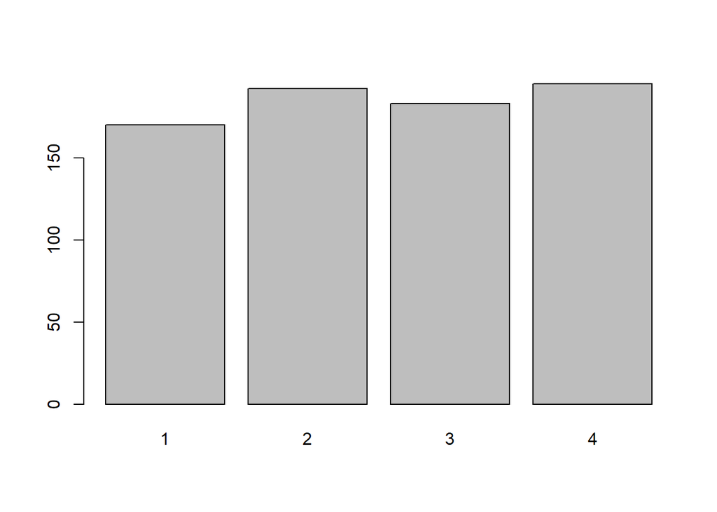

```
##   ID Reason.for.absence Month.of.absence Day.of.the.week Seasons
## 1 29                  0                9               2       4
## 2 29                 28                2               6       2
## 3 29                 19                5               4       3
## 4 29                 14                5               5       3
## 5 29                 22                5               6       3
##   Transportation.expense Distance.from.Residence.to.Work Service.time Age
## 1                    225                              26            9  28
## 2                    225                              15           15  41
## 3                    225                              15           15  41
## 4                    225                              15           15  41
## 5                    225                              15           15  41
##   Work.load.Average.day Hit.target Disciplinary.failure Education Son
## 1               241.476         92                    1         1   1
## 2               264.249         97                    0         4   2
## 3               237.656         99                    0         4   2
## 4               237.656         99                    0         4   2
## 5               237.656         99                    0         4   2
##   Social.drinker Social.smoker Pet Weight Height Body.mass.index
## 1              0             0   2     69    169              24
## 2              1             0   2     94    182              28
## 3              1             0   2     94    182              28
## 4              1             0   2     94    182              28
## 5              1             0   2     94    182              28
##   Absenteeism.time.in.hours
## 1                         0
## 2                         2
## 3                         3
## 4                         8
## 5                         8
```

```
## # A tibble: 2 x 2
##   ID    n_obs
##   <fct> <int>
## 1 28       76
## 2 29        1
```

```
##     ID Reason.for.absence Month.of.absence Day.of.the.week Seasons
## 738  4                  0                0               3       1
## 739  8                  0                0               4       2
## 740 35                  0                0               6       3
##     Transportation.expense Distance.from.Residence.to.Work Service.time Age
## 738                    118                              14           13  40
## 739                    231                              35           14  39
## 740                    179                              45           14  53
##     Work.load.Average.day Hit.target Disciplinary.failure Education Son
## 738               271.219         95                    0         1   1
## 739               271.219         95                    0         1   2
## 740               271.219         95                    0         1   1
##     Social.drinker Social.smoker Pet Weight Height Body.mass.index
## 738              1             0   8     98    170              34
## 739              1             0   2    100    170              35
## 740              0             0   1     77    175              25
##     Absenteeism.time.in.hours
## 738                         0
## 739                         0
## 740                         0
```

```
## # A tibble: 5 x 2
##   Month.of.absence n_obs
##   <fct>            <int>
## 1 0                    1
## 2 6                   16
## 3 9                   32
## 4 8                   54
## 5 7                   67
```

```
## # A tibble: 5 x 2
##   Month.of.absence n_obs
##   <fct>            <int>
## 1 0                    1
## 2 12                   9
## 3 1                   50
## 4 3                   60
## 5 2                   72
```

```
## # A tibble: 5 x 2
##   Month.of.absence n_obs
##   <fct>            <int>
## 1 0                    1
## 2 3                   27
## 3 6                   38
## 4 4                   53
## 5 5                   64
```

```
##     ID Reason.for.absence Month.of.absence Day.of.the.week Seasons
## 19   6                 11                7               5       1
## 52  29                  0                9               2       4
## 53  28                 23                9               3       4
## 57  28                 18                9               4       4
## 68  28                 23               10               6       4
## 70  28                 23               10               4       4
## 74  28                 23               10               4       4
## 77  28                 28               10               3       4
## 82  28                 23               11               4       4
## 87   6                 22               11               2       4
## 89  28                 23               11               4       4
## 91  28                 23               11               4       4
## 93  28                 13               11               6       4
## 96  28                 28               11               3       4
```

[output cut: 415 more lines]

```
##  0  1 10 11 12  2  3  4  5  6  7  8  9
##  0 50 71 63 49 72 88 54 64 54 68 54 53
```

```
## # A tibble: 1 x 2
##   ID    n_obs
##   <fct> <int>
## 1 28       77
```

Next, lets look at the first target variable, absenteeism in hours. I broke the target variable down into bins based on the structure of the responses. There were enough values for no callouts to be their own category, while absent days could be broken down into time off less than one day or greater than one day. I chose to group taking a full day off with taking more than one off because of the nature of callouts. Ultimately, this exercise seeks to find patterns in taking days off to detect fraudulent versus legitimate time off. Because of this, it’s unlikely that someone would only work part of a day if they were doing so fraudulently. This is supported by the reasons for absence. Taking less than one day off is mostly for miscellaneous reasons, like a dentist or doctor’s appointment. In contrast, taking more than one day off is more likely to be attributed to an ICD diagnosis. Finally, there is an extra value of ‘zero’ that was not defined as a reason for absence in the original data set description. This description is only present when the time taken off is also ‘zero’. However, for the models I’ll be creating regression trees that predict the number of hours given an absence.

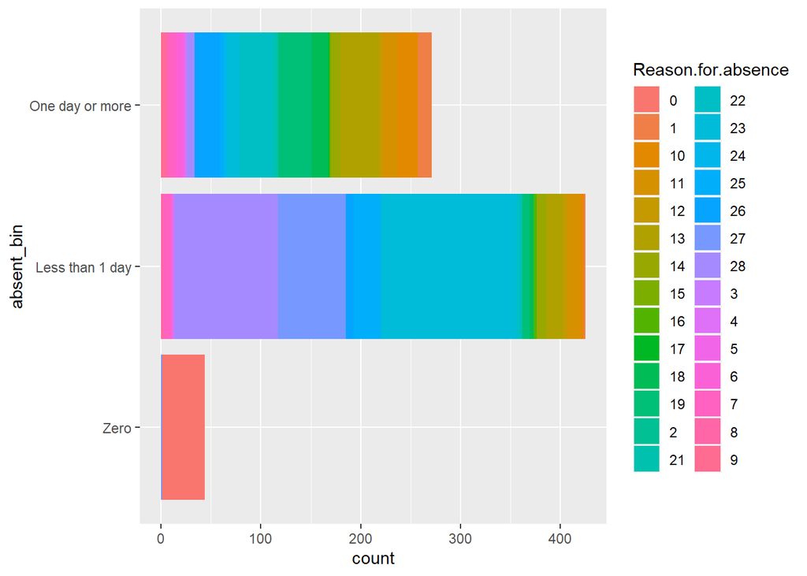

## Modeling the Data

### Absenteeism

For the first variable, I’m using the intended outcome variable of absenteeism in hours. I had to omit the ‘ID’ column as this is too many variables for the ‘tree’ function to consider.

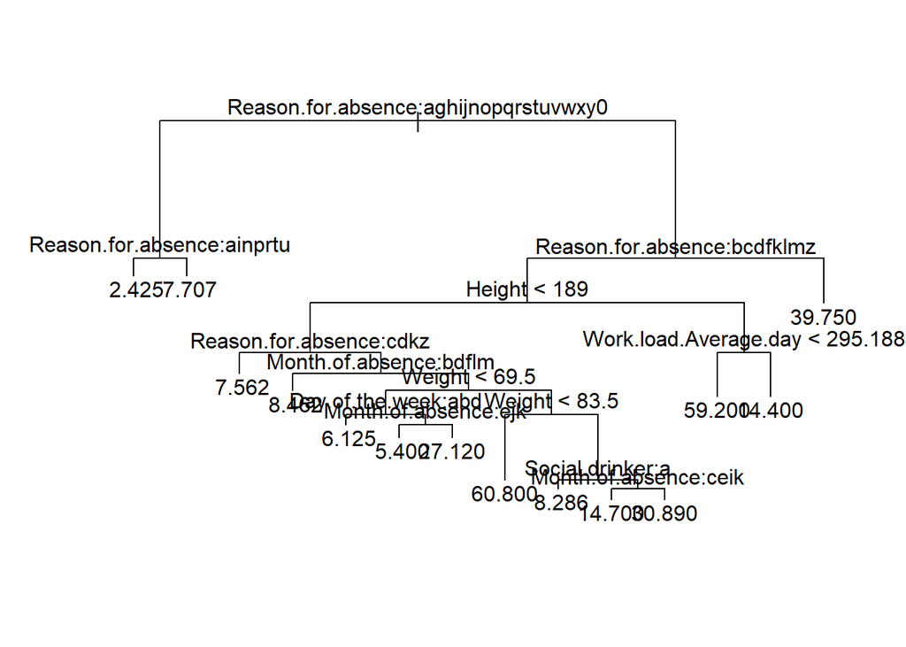

```
##
## Regression tree:
## tree(formula = Absenteeism.time.in.hours ~ . - ID, data = train)
## Variables actually used in tree construction:
## [1] "Reason.for.absence"    "Height"                "Month.of.absence"
## [4] "Weight"                "Day.of.the.week"       "Social.drinker"
## [7] "Work.load.Average.day"
## Number of terminal nodes:  14
## Residual mean deviance:  81.71 = 47230 / 578
## Distribution of residuals:
##     Min.  1st Qu.   Median     Mean  3rd Qu.     Max.
## -51.2000  -1.4250  -0.4247   0.0000   0.5753  73.1100
```

The decision tree model creates a tree with 14 nodes total. The most important nodes are the reasons for absence, as well as height and month of absence.

```
## [1] 242.9984
```

```
##
## Call:
##  randomForest(formula = Absenteeism.time.in.hours ~ . - ID, data = train,      mtry = 3, importance = TRUE, na.action = na.omit)
##                Type of random forest: regression
##                      Number of trees: 500
## No. of variables tried at each split: 3
##
##           Mean of squared residuals: 144.5725
##                     % Var explained: 14.61
```

```
##                                   %IncMSE IncNodePurity
## Reason.for.absence              12.529236     24392.545
## Month.of.absence                 3.319310      8470.681
## Day.of.the.week                  2.296452      4992.006
## Seasons                          4.129389      2823.696
## Transportation.expense           4.894875      3638.832
## Distance.from.Residence.to.Work  3.300605      2624.744
```

```
## [1] 185.727
```

Test performance is actually better using the random forest model for this outcome.

### Disciplinary Action

The second feature is less complicated than the intended target variable, which is the presence or absence of disciplinary action.

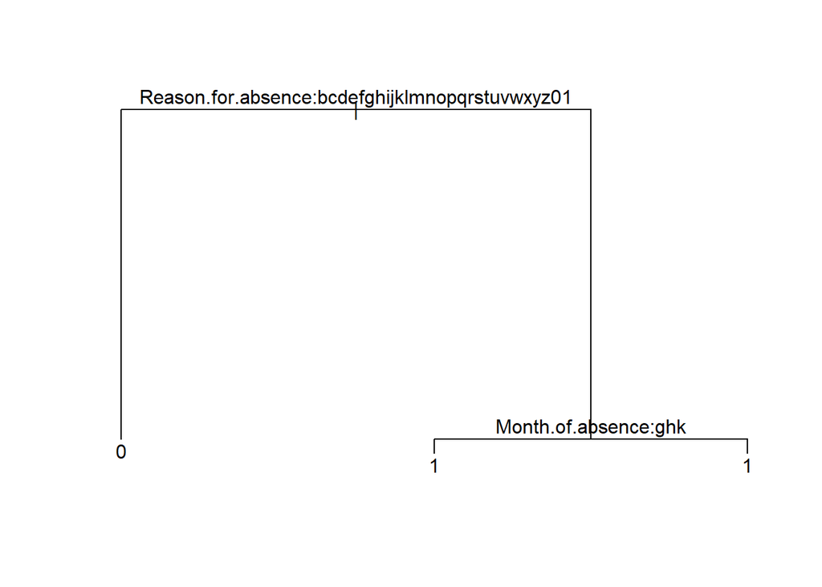

```
##
## Classification tree:
## tree(formula = Disciplinary.failure ~ . - ID, data = train)
## Variables actually used in tree construction:
## [1] "Reason.for.absence" "Month.of.absence"
## Number of terminal nodes:  3
## Residual mean deviance:  0.01797 = 10.59 / 589
## Misclassification error rate: 0.005068 = 3 / 592
```

Its decision tree is much simpler, with only 3 terminal nodes. The only variables considered are reasons for absence and its month. Misclassification is less than 1%.

```
##
## dt2_pred   0   1
##        0 143   0
##        1   0   5
```

For the test set, all classes are correctly predicted.

```
##
## Call:
##  randomForest(formula = Disciplinary.failure ~ . - ID, data = train,      mtry = 3, importance = TRUE, na.action = na.omit)
##                Type of random forest: classification
##                      Number of trees: 500
## No. of variables tried at each split: 3
##
##         OOB estimate of  error rate: 0.51%
## Confusion matrix:
##     0  1 class.error
## 0 554  3 0.005385996
## 1   0 35 0.000000000
```

```
##
## rf2_pred   0   1
##        0 143   0
##        1   0   5
```

The random forest model performed almost identically to the decision tree for the sample outcome variable.